# Risk Factor Analysis

## Outcome Variable

**Outcome Variable:** y_rate_haz

## Predictor Variables

**Intervention Variable:** exclfeed36

**Adjustment Set:**

unadjusted

## Stratifying Variables

The analysis was stratified on these variable(s):

- agecat
- studyid
- country

## Data Summary

| agecat | studyid | country | exclfeed36 | n_cell | n |
| --- | --- | --- | --- | --- | --- |
| 0-3 months | ki0047075b-MAL-ED | BANGLADESH | 0 | 180 | 242 |
| 0-3 months | ki0047075b-MAL-ED | BANGLADESH | 1 | 62 | 242 |
| 0-3 months | ki0047075b-MAL-ED | BRAZIL | 0 | 167 | 180 |
| 0-3 months | ki0047075b-MAL-ED | BRAZIL | 1 | 13 | 180 |
| 0-3 months | ki0047075b-MAL-ED | INDIA | 0 | 195 | 200 |
| 0-3 months | ki0047075b-MAL-ED | INDIA | 1 | 5 | 200 |
| 0-3 months | ki0047075b-MAL-ED | NEPAL | 0 | 163 | 175 |
| 0-3 months | ki0047075b-MAL-ED | NEPAL | 1 | 12 | 175 |
| 0-3 months | ki0047075b-MAL-ED | PERU | 0 | 254 | 269 |
| 0-3 months | ki0047075b-MAL-ED | PERU | 1 | 15 | 269 |
| 0-3 months | ki0047075b-MAL-ED | SOUTH AFRICA | 0 | 229 | 229 |
| 0-3 months | ki0047075b-MAL-ED | SOUTH AFRICA | 1 | 0 | 229 |
| 0-3 months | ki0047075b-MAL-ED | TANZANIA, UNITED REPUBLIC OF | 0 | 228 | 229 |
| 0-3 months | ki0047075b-MAL-ED | TANZANIA, UNITED REPUBLIC OF | 1 | 1 | 229 |
| 0-3 months | ki1000108-CMC-V-BCS-2002 | INDIA | 0 | 0 | 2 |
| 0-3 months | ki1000108-CMC-V-BCS-2002 | INDIA | 1 | 2 | 2 |
| 0-3 months | ki1000108-IRC | INDIA | 0 | 4 | 4 |
| 0-3 months | ki1000108-IRC | INDIA | 1 | 0 | 4 |
| 0-3 months | ki1000109-EE | PAKISTAN | 0 | 252 | 594 |
| 0-3 months | ki1000109-EE | PAKISTAN | 1 | 342 | 594 |
| 0-3 months | ki1017093b-PROVIDE | BANGLADESH | 0 | 459 | 628 |
| 0-3 months | ki1017093b-PROVIDE | BANGLADESH | 1 | 169 | 628 |
| 0-3 months | ki1101329-Keneba | GAMBIA | 0 | 790 | 1116 |
| 0-3 months | ki1101329-Keneba | GAMBIA | 1 | 326 | 1116 |
| 0-3 months | kiGH5241-JiVitA-3 | BANGLADESH | 0 | 6042 | 30184 |
| 0-3 months | kiGH5241-JiVitA-3 | BANGLADESH | 1 | 24142 | 30184 |
| 0-3 months | kiGH5241-JiVitA-4 | BANGLADESH | 0 | 572 | 3370 |
| 0-3 months | kiGH5241-JiVitA-4 | BANGLADESH | 1 | 2798 | 3370 |
| 3-6 months | ki0047075b-MAL-ED | BANGLADESH | 0 | 169 | 230 |
| 3-6 months | ki0047075b-MAL-ED | BANGLADESH | 1 | 61 | 230 |

[output cut: 92 more lines]

The following strata were considered:

- agecat: 0-3 months, studyid: ki0047075b-MAL-ED, country: BANGLADESH
- agecat: 0-3 months, studyid: ki0047075b-MAL-ED, country: BRAZIL
- agecat: 0-3 months, studyid: ki0047075b-MAL-ED, country: INDIA
- agecat: 0-3 months, studyid: ki0047075b-MAL-ED, country: NEPAL
- agecat: 0-3 months, studyid: ki0047075b-MAL-ED, country: PERU
- agecat: 0-3 months, studyid: ki0047075b-MAL-ED, country: SOUTH AFRICA
- agecat: 0-3 months, studyid: ki0047075b-MAL-ED, country: TANZANIA, UNITED REPUBLIC OF
- agecat: 0-3 months, studyid: ki1000108-CMC-V-BCS-2002, country: INDIA
- agecat: 0-3 months, studyid: ki1000108-IRC, country: INDIA
- agecat: 0-3 months, studyid: ki1000109-EE, country: PAKISTAN
- agecat: 0-3 months, studyid: ki1017093b-PROVIDE, country: BANGLADESH
- agecat: 0-3 months, studyid: ki1101329-Keneba, country: GAMBIA
- agecat: 0-3 months, studyid: kiGH5241-JiVitA-3, country: BANGLADESH
- agecat: 0-3 months, studyid: kiGH5241-JiVitA-4, country: BANGLADESH
- agecat: 12-24 months, studyid: ki0047075b-MAL-ED, country: BANGLADESH
- agecat: 12-24 months, studyid: ki0047075b-MAL-ED, country: BRAZIL
- agecat: 12-24 months, studyid: ki0047075b-MAL-ED, country: INDIA
- agecat: 12-24 months, studyid: ki0047075b-MAL-ED, country: NEPAL
- agecat: 12-24 months, studyid: ki0047075b-MAL-ED, country: PERU
- agecat: 12-24 months, studyid: ki0047075b-MAL-ED, country: SOUTH AFRICA
- agecat: 12-24 months, studyid: ki0047075b-MAL-ED, country: TANZANIA, UNITED REPUBLIC OF
- agecat: 12-24 months, studyid: ki1000108-CMC-V-BCS-2002, country: INDIA
- agecat: 12-24 months, studyid: ki1000108-IRC, country: INDIA
- agecat: 12-24 months, studyid: ki1017093b-PROVIDE, country: BANGLADESH
- agecat: 12-24 months, studyid: ki1101329-Keneba, country: GAMBIA
- agecat: 12-24 months, studyid: ki1113344-GMS-Nepal, country: NEPAL
- agecat: 12-24 months, studyid: ki1148112-LCNI-5, country: MALAWI
- agecat: 12-24 months, studyid: kiGH5241-JiVitA-3, country: BANGLADESH
- agecat: 12-24 months, studyid: kiGH5241-JiVitA-4, country: BANGLADESH
- agecat: 3-6 months, studyid: ki0047075b-MAL-ED, country: BANGLADESH
- agecat: 3-6 months, studyid: ki0047075b-MAL-ED, country: BRAZIL
- agecat: 3-6 months, studyid: ki0047075b-MAL-ED, country: INDIA
- agecat: 3-6 months, studyid: ki0047075b-MAL-ED, country: NEPAL
- agecat: 3-6 months, studyid: ki0047075b-MAL-ED, country: PERU
- agecat: 3-6 months, studyid: ki0047075b-MAL-ED, country: SOUTH AFRICA
- agecat: 3-6 months, studyid: ki0047075b-MAL-ED, country: TANZANIA, UNITED REPUBLIC OF
- agecat: 3-6 months, studyid: ki1000108-CMC-V-BCS-2002, country: INDIA
- agecat: 3-6 months, studyid: ki1000108-IRC, country: INDIA
- agecat: 3-6 months, studyid: ki1000109-EE, country: PAKISTAN
- agecat: 3-6 months, studyid: ki1017093b-PROVIDE, country: BANGLADESH
- agecat: 3-6 months, studyid: ki1101329-Keneba, country: GAMBIA
- agecat: 3-6 months, studyid: ki1113344-GMS-Nepal, country: NEPAL
- agecat: 3-6 months, studyid: kiGH5241-JiVitA-3, country: BANGLADESH
- agecat: 3-6 months, studyid: kiGH5241-JiVitA-4, country: BANGLADESH
- agecat: 6-12 months, studyid: ki0047075b-MAL-ED, country: BANGLADESH
- agecat: 6-12 months, studyid: ki0047075b-MAL-ED, country: BRAZIL
- agecat: 6-12 months, studyid: ki0047075b-MAL-ED, country: INDIA
- agecat: 6-12 months, studyid: ki0047075b-MAL-ED, country: NEPAL
- agecat: 6-12 months, studyid: ki0047075b-MAL-ED, country: PERU
- agecat: 6-12 months, studyid: ki0047075b-MAL-ED, country: SOUTH AFRICA
- agecat: 6-12 months, studyid: ki0047075b-MAL-ED, country: TANZANIA, UNITED REPUBLIC OF
- agecat: 6-12 months, studyid: ki1000108-CMC-V-BCS-2002, country: INDIA
- agecat: 6-12 months, studyid: ki1000108-IRC, country: INDIA
- agecat: 6-12 months, studyid: ki1000109-EE, country: PAKISTAN
- agecat: 6-12 months, studyid: ki1000304b-SAS-FoodSuppl, country: INDIA
- agecat: 6-12 months, studyid: ki1017093b-PROVIDE, country: BANGLADESH
- agecat: 6-12 months, studyid: ki1101329-Keneba, country: GAMBIA
- agecat: 6-12 months, studyid: ki1113344-GMS-Nepal, country: NEPAL
- agecat: 6-12 months, studyid: ki1148112-LCNI-5, country: MALAWI
- agecat: 6-12 months, studyid: kiGH5241-JiVitA-3, country: BANGLADESH
- agecat: 6-12 months, studyid: kiGH5241-JiVitA-4, country: BANGLADESH

### Dropped Strata

Some strata were dropped due to rare outcomes:

- agecat: 0-3 months, studyid: ki0047075b-MAL-ED, country: SOUTH AFRICA
- agecat: 0-3 months, studyid: ki0047075b-MAL-ED, country: TANZANIA, UNITED REPUBLIC OF
- agecat: 0-3 months, studyid: ki1000108-CMC-V-BCS-2002, country: INDIA
- agecat: 0-3 months, studyid: ki1000108-IRC, country: INDIA
- agecat: 3-6 months, studyid: ki0047075b-MAL-ED, country: SOUTH AFRICA
- agecat: 3-6 months, studyid: ki0047075b-MAL-ED, country: TANZANIA, UNITED REPUBLIC OF
- agecat: 3-6 months, studyid: ki1000108-CMC-V-BCS-2002, country: INDIA
- agecat: 3-6 months, studyid: ki1000108-IRC, country: INDIA
- agecat: 6-12 months, studyid: ki0047075b-MAL-ED, country: SOUTH AFRICA
- agecat: 6-12 months, studyid: ki0047075b-MAL-ED, country: TANZANIA, UNITED REPUBLIC OF
- agecat: 6-12 months, studyid: ki1000108-CMC-V-BCS-2002, country: INDIA
- agecat: 6-12 months, studyid: ki1000108-IRC, country: INDIA
- agecat: 6-12 months, studyid: ki1000109-EE, country: PAKISTAN
- agecat: 6-12 months, studyid: ki1000304b-SAS-FoodSuppl, country: INDIA
- agecat: 12-24 months, studyid: ki0047075b-MAL-ED, country: SOUTH AFRICA
- agecat: 12-24 months, studyid: ki0047075b-MAL-ED, country: TANZANIA, UNITED REPUBLIC OF
- agecat: 12-24 months, studyid: ki1000108-CMC-V-BCS-2002, country: INDIA
- agecat: 12-24 months, studyid: ki1000108-IRC, country: INDIA

## Methods Detail

We’re interested in the causal parameters $E[Y_a]$ for all values of $a \in \mathcal{A}$. These parameters represent the mean outcome if, possibly contrary to fact, we intervened to set all units to have $A=a$. Under the randomization and positivity assumptions, these are identified by the statistical parameters $\psi_a=E_W[E_{Y|A,W}(Y|A=a,W)]$. In addition, we’re interested in the mean of $Y$, $E[Y]$ under no intervention (the observed mean). We will estimate these parameters by using SuperLearner to fit the relevant likelihood factors – $E_{Y|A,W}(Y|A=a,W)$ and $p(A=a|W)$, and then updating our likelihood fit using a joint TMLE.

For unadjusted analyses ($W=\{\}$), initial likelihoods were estimated using Lrnr_glm to estimate the simple $E(Y|A)$ and Lrnr_mean to estimate $p(A)$. For adjusted analyses, a small library containing Lrnr_glmnet, Lrnr_xgboost, and Lrnr_mean was used.

Having estimated these parameters, we will then use the delta method to estimate relative risks and attributable risks relative to a prespecified baseline level of $A$.

# Results Detail

## Results Plots

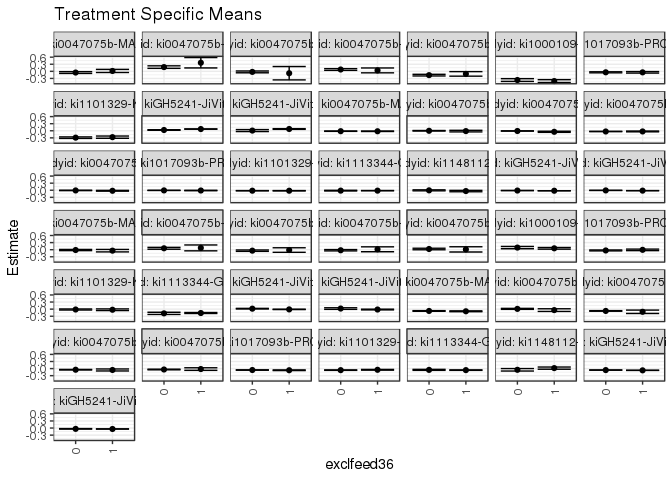

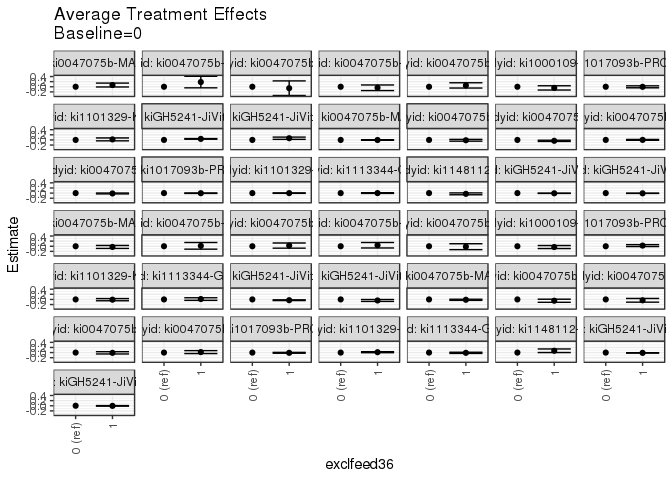

## Results Table

### Parameter: TSM

| agecat | studyid | country | intervention_level | baseline_level | estimate | ci_lower | ci_upper |
| --- | --- | --- | --- | --- | --- | --- | --- |
| 0-3 months | ki0047075b-MAL-ED | BANGLADESH | 0 | NA | -0.0513990 | -0.0881389 | -0.0146592 |
| 0-3 months | ki0047075b-MAL-ED | BANGLADESH | 1 | NA | 0.0155796 | -0.0501665 | 0.0813257 |
| 0-3 months | ki0047075b-MAL-ED | BRAZIL | 0 | NA | 0.1795759 | 0.1267856 | 0.2323662 |
| 0-3 months | ki0047075b-MAL-ED | BRAZIL | 1 | NA | 0.3634914 | 0.1437001 | 0.5832827 |
| 0-3 months | ki0047075b-MAL-ED | INDIA | 0 | NA | -0.0240354 | -0.0624725 | 0.0144017 |
| 0-3 months | ki0047075b-MAL-ED | INDIA | 1 | NA | -0.0804111 | -0.3634633 | 0.2026411 |
| 0-3 months | ki0047075b-MAL-ED | NEPAL | 0 | NA | 0.0772801 | 0.0404062 | 0.1141539 |
| 0-3 months | ki0047075b-MAL-ED | NEPAL | 1 | NA | 0.0384906 | -0.0644362 | 0.1414174 |
| 0-3 months | ki0047075b-MAL-ED | PERU | 0 | NA | -0.1615637 | -0.1957467 | -0.1273807 |
| 0-3 months | ki0047075b-MAL-ED | PERU | 1 | NA | -0.1085253 | -0.2049851 | -0.0120655 |
| 0-3 months | ki1000109-EE | PAKISTAN | 0 | NA | -0.3682845 | -0.4260295 | -0.3105395 |
| 0-3 months | ki1000109-EE | PAKISTAN | 1 | NA | -0.4126906 | -0.4730866 | -0.3522946 |
| 0-3 months | ki1017093b-PROVIDE | BANGLADESH | 0 | NA | -0.0409817 | -0.0628594 | -0.0191039 |
| 0-3 months | ki1017093b-PROVIDE | BANGLADESH | 1 | NA | -0.0433848 | -0.0749913 | -0.0117784 |
| 0-3 months | ki1101329-Keneba | GAMBIA | 0 | NA | -0.2906328 | -0.3221309 | -0.2591346 |
| 0-3 months | ki1101329-Keneba | GAMBIA | 1 | NA | -0.2694097 | -0.3164481 | -0.2223713 |
| 0-3 months | kiGH5241-JiVitA-3 | BANGLADESH | 0 | NA | 0.0327864 | 0.0210444 | 0.0445283 |
| 0-3 months | kiGH5241-JiVitA-3 | BANGLADESH | 1 | NA | 0.0733044 | 0.0672657 | 0.0793432 |
| 0-3 months | kiGH5241-JiVitA-4 | BANGLADESH | 0 | NA | 0.0085509 | -0.0327465 | 0.0498484 |
| 0-3 months | kiGH5241-JiVitA-4 | BANGLADESH | 1 | NA | 0.0756007 | 0.0594935 | 0.0917080 |
| 3-6 months | ki0047075b-MAL-ED | BANGLADESH | 0 | NA | -0.0140488 | -0.0391598 | 0.0110623 |
| 3-6 months | ki0047075b-MAL-ED | BANGLADESH | 1 | NA | -0.0411553 | -0.0931058 | 0.0107952 |
| 3-6 months | ki0047075b-MAL-ED | BRAZIL | 0 | NA | 0.0591447 | 0.0209661 | 0.0973233 |
| 3-6 months | ki0047075b-MAL-ED | BRAZIL | 1 | NA | 0.0756099 | -0.0493475 | 0.2005673 |
| 3-6 months | ki0047075b-MAL-ED | INDIA | 0 | NA | -0.0409254 | -0.0700583 | -0.0117925 |
| 3-6 months | ki0047075b-MAL-ED | INDIA | 1 | NA | -0.0147452 | -0.1112534 | 0.0817630 |
| 3-6 months | ki0047075b-MAL-ED | NEPAL | 0 | NA | -0.0238813 | -0.0513564 | 0.0035937 |
| 3-6 months | ki0047075b-MAL-ED | NEPAL | 1 | NA | 0.0165140 | -0.0870054 | 0.1200335 |
| 3-6 months | ki0047075b-MAL-ED | PERU | 0 | NA | 0.0290615 | -0.0032656 | 0.0613886 |
| 3-6 months | ki0047075b-MAL-ED | PERU | 1 | NA | 0.0123274 | -0.0982789 | 0.1229337 |

[output cut: 56 more lines]

### Parameter: E(Y)

| agecat | studyid | country | intervention_level | baseline_level | estimate | ci_lower | ci_upper |
| --- | --- | --- | --- | --- | --- | --- | --- |
| 0-3 months | ki0047075b-MAL-ED | BANGLADESH | NA | NA | -0.0342392 | -0.0665521 | -0.0019264 |
| 0-3 months | ki0047075b-MAL-ED | BRAZIL | NA | NA | 0.1928587 | 0.1409027 | 0.2448147 |
| 0-3 months | ki0047075b-MAL-ED | INDIA | NA | NA | -0.0254448 | -0.0636028 | 0.0127132 |
| 0-3 months | ki0047075b-MAL-ED | NEPAL | NA | NA | 0.0746202 | 0.0395269 | 0.1097135 |
| 0-3 months | ki0047075b-MAL-ED | PERU | NA | NA | -0.1586062 | -0.1913606 | -0.1258518 |
| 0-3 months | ki1000109-EE | PAKISTAN | NA | NA | -0.3938516 | -0.4364614 | -0.3512419 |
| 0-3 months | ki1017093b-PROVIDE | BANGLADESH | NA | NA | -0.0416284 | -0.0597402 | -0.0235165 |
| 0-3 months | ki1101329-Keneba | GAMBIA | NA | NA | -0.2844332 | -0.3106302 | -0.2582362 |
| 0-3 months | kiGH5241-JiVitA-3 | BANGLADESH | NA | NA | 0.0651938 | 0.0595783 | 0.0708094 |
| 0-3 months | kiGH5241-JiVitA-4 | BANGLADESH | NA | NA | 0.0642202 | 0.0489852 | 0.0794552 |
| 3-6 months | ki0047075b-MAL-ED | BANGLADESH | NA | NA | -0.0212379 | -0.0443179 | 0.0018421 |
| 3-6 months | ki0047075b-MAL-ED | BRAZIL | NA | NA | 0.0604904 | 0.0239698 | 0.0970111 |
| 3-6 months | ki0047075b-MAL-ED | INDIA | NA | NA | -0.0401251 | -0.0685271 | -0.0117231 |
| 3-6 months | ki0047075b-MAL-ED | NEPAL | NA | NA | -0.0214542 | -0.0480456 | 0.0051373 |
| 3-6 months | ki0047075b-MAL-ED | PERU | NA | NA | 0.0280549 | -0.0030513 | 0.0591612 |
| 3-6 months | ki1000109-EE | PAKISTAN | NA | NA | 0.0701161 | 0.0419135 | 0.0983187 |
| 3-6 months | ki1017093b-PROVIDE | BANGLADESH | NA | NA | -0.0262004 | -0.0425541 | -0.0098466 |
| 3-6 months | ki1101329-Keneba | GAMBIA | NA | NA | -0.0181994 | -0.0377516 | 0.0013528 |
| 3-6 months | ki1113344-GMS-Nepal | NEPAL | NA | NA | -0.1671388 | -0.1860153 | -0.1482623 |
| 3-6 months | kiGH5241-JiVitA-3 | BANGLADESH | NA | NA | -0.0050971 | -0.0104963 | 0.0003021 |
| 3-6 months | kiGH5241-JiVitA-4 | BANGLADESH | NA | NA | -0.0093314 | -0.0232659 | 0.0046030 |
| 6-12 months | ki0047075b-MAL-ED | BANGLADESH | NA | NA | -0.0808013 | -0.0912137 | -0.0703889 |
| 6-12 months | ki0047075b-MAL-ED | BRAZIL | NA | NA | 0.0065644 | -0.0129183 | 0.0260472 |
| 6-12 months | ki0047075b-MAL-ED | INDIA | NA | NA | -0.0776724 | -0.0898619 | -0.0654829 |
| 6-12 months | ki0047075b-MAL-ED | NEPAL | NA | NA | -0.0488126 | -0.0594641 | -0.0381610 |
| 6-12 months | ki0047075b-MAL-ED | PERU | NA | NA | -0.0373127 | -0.0513600 | -0.0232653 |
| 6-12 months | ki1017093b-PROVIDE | BANGLADESH | NA | NA | -0.0626151 | -0.0695574 | -0.0556729 |
| 6-12 months | ki1101329-Keneba | GAMBIA | NA | NA | -0.0616584 | -0.0698107 | -0.0535060 |
| 6-12 months | ki1113344-GMS-Nepal | NEPAL | NA | NA | -0.0626340 | -0.0709302 | -0.0543379 |
| 6-12 months | ki1148112-LCNI-5 | MALAWI | NA | NA | -0.0281085 | -0.0675243 | 0.0113073 |
| 6-12 months | kiGH5241-JiVitA-3 | BANGLADESH | NA | NA | -0.0720156 | -0.0751021 | -0.0689290 |
| 6-12 months | kiGH5241-JiVitA-4 | BANGLADESH | NA | NA | -0.0387210 | -0.0435056 | -0.0339363 |
| 12-24 months | ki0047075b-MAL-ED | BANGLADESH | NA | NA | -0.0177078 | -0.0231267 | -0.0122889 |
| 12-24 months | ki0047075b-MAL-ED | BRAZIL | NA | NA | -0.0013016 | -0.0119070 | 0.0093038 |
| 12-24 months | ki0047075b-MAL-ED | INDIA | NA | NA | -0.0098833 | -0.0150187 | -0.0047479 |
| 12-24 months | ki0047075b-MAL-ED | NEPAL | NA | NA | -0.0295113 | -0.0345712 | -0.0244514 |
| 12-24 months | ki0047075b-MAL-ED | PERU | NA | NA | -0.0092560 | -0.0162726 | -0.0022393 |
| 12-24 months | ki1017093b-PROVIDE | BANGLADESH | NA | NA | -0.0080793 | -0.0119248 | -0.0042338 |
| 12-24 months | ki1101329-Keneba | GAMBIA | NA | NA | -0.0198482 | -0.0237984 | -0.0158981 |
| 12-24 months | ki1113344-GMS-Nepal | NEPAL | NA | NA | -0.0170788 | -0.0222320 | -0.0119257 |
| 12-24 months | ki1148112-LCNI-5 | MALAWI | NA | NA | -0.0140852 | -0.0319419 | 0.0037715 |
| 12-24 months | kiGH5241-JiVitA-3 | BANGLADESH | NA | NA | -0.0193591 | -0.0213957 | -0.0173226 |
| 12-24 months | kiGH5241-JiVitA-4 | BANGLADESH | NA | NA | -0.0147196 | -0.0167684 | -0.0126707 |

### Parameter: ATE

| agecat | studyid | country | intervention_level | baseline_level | estimate | ci_lower | ci_upper |
| --- | --- | --- | --- | --- | --- | --- | --- |
| 0-3 months | ki0047075b-MAL-ED | BANGLADESH | 0 | 0 | 0.0000000 | 0.0000000 | 0.0000000 |
| 0-3 months | ki0047075b-MAL-ED | BANGLADESH | 1 | 0 | 0.0669787 | -0.0083365 | 0.1422938 |
| 0-3 months | ki0047075b-MAL-ED | BRAZIL | 0 | 0 | 0.0000000 | 0.0000000 | 0.0000000 |
| 0-3 months | ki0047075b-MAL-ED | BRAZIL | 1 | 0 | 0.1839155 | -0.0421266 | 0.4099576 |
| 0-3 months | ki0047075b-MAL-ED | INDIA | 0 | 0 | 0.0000000 | 0.0000000 | 0.0000000 |
| 0-3 months | ki0047075b-MAL-ED | INDIA | 1 | 0 | -0.0563757 | -0.3420257 | 0.2292744 |
| 0-3 months | ki0047075b-MAL-ED | NEPAL | 0 | 0 | 0.0000000 | 0.0000000 | 0.0000000 |
| 0-3 months | ki0047075b-MAL-ED | NEPAL | 1 | 0 | -0.0387895 | -0.1481220 | 0.0705430 |
| 0-3 months | ki0047075b-MAL-ED | PERU | 0 | 0 | 0.0000000 | 0.0000000 | 0.0000000 |
| 0-3 months | ki0047075b-MAL-ED | PERU | 1 | 0 | 0.0530384 | -0.0492991 | 0.1553759 |
| 0-3 months | ki1000109-EE | PAKISTAN | 0 | 0 | 0.0000000 | 0.0000000 | 0.0000000 |
| 0-3 months | ki1000109-EE | PAKISTAN | 1 | 0 | -0.0444060 | -0.1279653 | 0.0391533 |
| 0-3 months | ki1017093b-PROVIDE | BANGLADESH | 0 | 0 | 0.0000000 | 0.0000000 | 0.0000000 |
| 0-3 months | ki1017093b-PROVIDE | BANGLADESH | 1 | 0 | -0.0024032 | -0.0408428 | 0.0360364 |
| 0-3 months | ki1101329-Keneba | GAMBIA | 0 | 0 | 0.0000000 | 0.0000000 | 0.0000000 |
| 0-3 months | ki1101329-Keneba | GAMBIA | 1 | 0 | 0.0212230 | -0.0353874 | 0.0778335 |
| 0-3 months | kiGH5241-JiVitA-3 | BANGLADESH | 0 | 0 | 0.0000000 | 0.0000000 | 0.0000000 |
| 0-3 months | kiGH5241-JiVitA-3 | BANGLADESH | 1 | 0 | 0.0405181 | 0.0279391 | 0.0530971 |
| 0-3 months | kiGH5241-JiVitA-4 | BANGLADESH | 0 | 0 | 0.0000000 | 0.0000000 | 0.0000000 |
| 0-3 months | kiGH5241-JiVitA-4 | BANGLADESH | 1 | 0 | 0.0670498 | 0.0227893 | 0.1113102 |
| 3-6 months | ki0047075b-MAL-ED | BANGLADESH | 0 | 0 | 0.0000000 | 0.0000000 | 0.0000000 |
| 3-6 months | ki0047075b-MAL-ED | BANGLADESH | 1 | 0 | -0.0271065 | -0.0848077 | 0.0305946 |
| 3-6 months | ki0047075b-MAL-ED | BRAZIL | 0 | 0 | 0.0000000 | 0.0000000 | 0.0000000 |
| 3-6 months | ki0047075b-MAL-ED | BRAZIL | 1 | 0 | 0.0164652 | -0.1141944 | 0.1471249 |
| 3-6 months | ki0047075b-MAL-ED | INDIA | 0 | 0 | 0.0000000 | 0.0000000 | 0.0000000 |
| 3-6 months | ki0047075b-MAL-ED | INDIA | 1 | 0 | 0.0261802 | -0.0746293 | 0.1269897 |
| 3-6 months | ki0047075b-MAL-ED | NEPAL | 0 | 0 | 0.0000000 | 0.0000000 | 0.0000000 |
| 3-6 months | ki0047075b-MAL-ED | NEPAL | 1 | 0 | 0.0403954 | -0.0667081 | 0.1474989 |
| 3-6 months | ki0047075b-MAL-ED | PERU | 0 | 0 | 0.0000000 | 0.0000000 | 0.0000000 |
| 3-6 months | ki0047075b-MAL-ED | PERU | 1 | 0 | -0.0167341 | -0.1319678 | 0.0984995 |

[output cut: 56 more lines]